# Clase 8: Pesca industrial y Espacios Costeros Marinos de Pueblos Originarios (ECMPO)

Mapeando la (In)sustentabilidad · SUS2211 · Pontificia Universidad Católica de Chile

## Objetivo

El objetivo de esta práctica es que detectes y representes visualmente **lances de pesca industrial** que ocurrieron **dentro o cerca** de los **Espacios Costeros Marinos de Pueblos Originarios (ECMPO)**. En el camino aprenderás a **limpiar datos defectuosos**, a **validar espacial y temporalmente** tus registros, y a **comunicar resultados con mapas claros**.

**Herramientas por trabajar:**

- Carga de datos tabulares (CSV) a QGIS
- GeoPackage como formato de trabajo
- Calculadora de Campos (limpieza por orden de magnitud geográfico)
- Selección por expresión y por localización
- Buffer, Disolver, Diferencia e Intersección
- Constructor de consultas (filtro de capa)
- Composición de impresión para mapas comparativos

**Advertencia**

**¡Importante!** Si estás trabajando en un computador de la universidad, no olvides guardar tu trabajo en **OneDrive** (u otro servicio en la nube), de lo contrario perderás tu avance. Los computadores de la sala de clases se **borran automáticamente cada semana**.

## Resumen del trabajo de esta clase

### Capas

| Capa | Descripción |
| --- | --- |
| **a)** `lances.csv` | Registro tabular de viajes y lances de pesca industrial (cada fila es un lance, con longitud/latitud de inicio y fin) |
| **b)** `ECMPO.gpkg` | Polígonos de los Espacios Costeros Marinos de Pueblos Originarios solicitados y/o decretados |
| **c)** `ZEE_Chile.gpkg` | Polígono de la Zona Económica Exclusiva de Chile (mar jurisdiccional, 370,4 km desde la costa) |

### Procesos

1. **Pasos 1–4 — Preparación y reproyección.** Cargar el CSV como capa de puntos, exportar a GeoPackage y reproyectar todas las capas a **EPSG:3857** (metros).
2. **Pasos 5–7 — Limpieza.** Aplicar un **orden de magnitud geográfico** a las coordenadas para eliminar registros corruptos o fuera de Chile, y filtrar solo las ECMPO con estado `SECTOR DECRETADO`.
3. **Pasos 8–14 — Análisis espacial.**
   - **A) Paso 8:** filtrar los lances que caen dentro de la **ZEE** de Chile.
   - **B) Pasos 9–11:** construir un **buffer de 5 km** alrededor de cada ECMPO decretada, disolverlo y calcular su **anillo externo** (buffer sin el polígono original).
   - **C) Paso 12:** intersectar los lances con (i) las ECMPO y (ii) el anillo externo.
   - **D) Pasos 13–14:** clasificar los lances por **zona** (Dentro / Borde) y por **periodo** (Antes / Después del decreto).
4. **Pasos 15–16 — Confección de mapas temáticos.** Dos mapas comparativos (antes vs. después del decreto) enfocados en una región a elección.

## Preparación: descarga y organización del material

### Descarga desde Canvas

**1.** Descarga el archivo `.zip` de esta tarea desde la página del curso en **Canvas** (carpeta “Clase 8”). El archivo contiene todas las capas necesarias para el ejercicio.

**2.** Descomprime el archivo en una ubicación dedicada a este curso. Algunas opciones:

- **Computador personal:** descomprime dentro de tu carpeta `SUS2211/`.
- **Computador de la sala:** descomprime en el escritorio o en Documentos, pero **antes de terminar la sesión**, copia toda la carpeta a OneDrive, un pendrive u otro servicio en la nube.

### Estructura de carpetas del proyecto

Al descomprimir el archivo, encontrarás la siguiente estructura de carpetas. Esta organización es la misma que hemos usado en clases anteriores y es **estándar para todas las tareas del curso**.

```
flowchart TD
    A["📁 clase8/"] --> B["📁 datos/"]
    A --> C["📁 documentos/"]
    A --> D["📁 proyectos/"]
    A --> E["📁 resultados/"]

    B --> F["📁 brutos/<br>🔒 datos originales<br>(no modificar)"]
    B --> G["📁 intermedios/<br>datos de geoprocesamiento"]
    B --> H["📁 procesados/<br>capas finales para mapeo"]

    E --> I["📁 mapas/<br>mapas exportados"]
    E --> J["📁 figuras/<br>gráficos y tablas"]

    style F fill:#fde8e8,stroke:#c0392b
    style G fill:#fef9e7,stroke:#f39c12
    style H fill:#eafaf1,stroke:#27ae60
    style D fill:#eaf4fb,stroke:#2980b9
    style C fill:#f4f6f7,stroke:#7f8c8d
```

**Tip¿Para qué sirve cada carpeta?**

**`datos/`** — Todo lo relacionado con los datos geoespaciales, organizado en tres subcarpetas:

- **`brutos/`** 🔒 Datos originales tal como fueron descargados. **Nunca se modifican ni se sobreescriben.** En esta tarea: `lances.csv`, `ECMPO.gpkg` y `ZEE_Chile.gpkg`.
- **`intermedios/`** Resultados de operaciones de geoprocesamiento. En esta tarea: `lance(3857).gpkg`, `lances_filtrados.gpkg`, `ecmpo_decretadas.gpkg`, `lances_chile_ZEE.gpkg`, `buffer_ecmpo_5km.gpkg`, `buffer_ecmpo_disueltos.gpkg`, `anillo_externo_ecmpo.gpkg`.
- **`procesados/`** Capas finales listas para confeccionar los mapas. En esta tarea: `Lances_dentro_ECMPO.gpkg` y `lances_borde_ecmpo.gpkg` con los campos `zona` y `periodo` ya calculados.

**`documentos/`** — Documentación de respaldo. Se recomienda incluir una bitácora (`bitacora.txt` o `pasos.md`) que describa cómo transformaste los datos.

**`proyectos/`** — Archivos de proyecto QGIS (`.qgz`). Guarda aquí el proyecto de esta tarea, nómbralo `clase8.qgz`.

**`resultados/`** — Productos finales:

- **`mapas/`** Los dos mapas comparativos (antes y después del decreto) exportados a PDF o imagen.
- **`figuras/`** Gráficos, tablas u otros outputs.

### Material descargado

Dentro de `datos/brutos/` encontrarás los siguientes archivos:

| Archivo | Descripción |
| --- | --- |
| `lances.csv` | Tabla de lances de pesca industrial (cada fila: un lance con fecha, embarcación, puerto de zarpe/recalada, especie y coordenadas de inicio y fin de lance) |
| `ECMPO` (.gpkg) | Polígonos de ECMPO solicitados y/o decretados, con atributos como `status`, `dateDecree`, `decreeNum`, `name`, `applicant`, `region` |
| `ZEE_Chile` (.gpkg) | Polígono de la Zona Económica Exclusiva chilena |

## Paso 1 | Crear el proyecto y activar el mapa base

**1.** Inicia QGIS en el computador.

**2.** Crea un proyecto nuevo a partir de un mapa (recuerda nombrarlo bajo el nombre de la clase correspondiente y guardarlo en **OneDrive**).

[figure not shown]

Crear un proyecto nuevo en QGIS.

**3.** Como ya lo hemos configurado en clases anteriores, para una mejor visualización activaremos un **mapa base**. Ve a la barra de herramientas superior: **Web → QuickMapServices → OSM → OSM Standard**.

[figure not shown]

Activar OSM Standard como mapa base.

**Advertencia**

En clases anteriores hemos configurado el mapa base en escala de grises y añadido transparencia, para que no quite protagonismo a las capas del mapa. En este caso no es necesario, dado que la acción del mapa ocurre en el mar, y el mapa base no tiene elementos distractivos en el mar.

**Nota**

**PAUSA** — hasta ahora debería visualizarse algo así:

[figure not shown]

Mapa base cargado en QGIS, centrado en Chile.

## Paso 2 | Cargar el CSV de lances de pesca industrial

**Tip**

**¿Qué es un lance?** Un lance es una **instancia concreta de pesca dentro de un viaje**: cuando el barco se detiene (o anda muy lento) para echar su arte de pesca. Un mismo viaje puede contener varios lances en posiciones distintas. Cada fila del CSV representa un lance y trae las coordenadas de inicio y fin.

**4.** Debes cargar el CSV a QGIS. Ve a: **Capa → Añadir capa → Añadir capa de texto delimitado**.

[figure not shown]

Menú Añadir capa de texto delimitado.

**5.** Selecciona el archivo `lances.csv` y configura:

- **Nombre de la capa:** `Lances`
- **Formato de archivo:** CSV (valores separados por coma)
- **Definición de geometría:** Coordenadas de punto
  - **Campo X (longitud):** `LONGITUD INICIO DE LANCE`
  - **Campo Y (latitud):** `LATITUD INICIO DE LANCE`
- **SRC de la geometría:** `EPSG:4326 - WGS 84`

Haz clic en **Añadir**.

[figure not shown]

Configuración del diálogo de CSV: formato, coordenadas X/Y y CRS EPSG:4326.

**Nota**

**PAUSA** — esto crea una capa de puntos con el **inicio de cada lance**. Debería visualizarse así (fíjate que hay puntos claramente fuera de Chile — los vamos a limpiar más adelante):

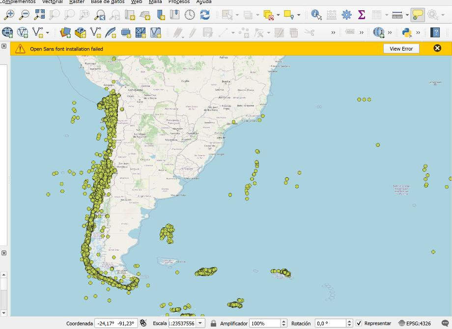

Puntos de inicio de lance sobre el mapa base, con outliers en el Atlántico y fuera del territorio chileno.

## Paso 3 | Exportar los lances a GeoPackage en EPSG:3857

**Tip**

**¿Por qué reproyectar a EPSG:3857?** El resto de este análisis necesita **medir distancias en metros** (buffers de 5 km, por ejemplo). Para eso necesitamos un sistema de coordenadas **proyectado** cuya unidad sea el metro. Usaremos **EPSG:3857 – WGS 84 / Pseudo Mercator**, que es el mismo sistema del mapa base.

**6.** Haz clic derecho sobre la capa de puntos recién cargada (`Lances`) → **Exportar → Guardar objetos como…**

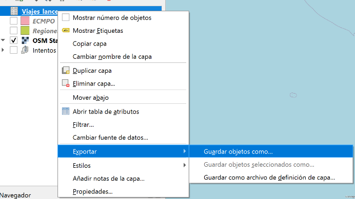

Menú contextual Exportar > Guardar objetos como.

**7.** Configura:

- **Formato:** GeoPackage
- **Nombre de archivo:** `lance(3857)`
- **Nombre de la capa:** `lance(3857)`
- **SRC:** `EPSG:3857 - WGS 84 / Pseudo Mercator`

Haz clic en **Aceptar**.

[figure not shown]

Guardar capa vectorial como GeoPackage en EPSG:3857.

## Paso 4 | Reproyectar la capa ECMPO a EPSG:3857

**8.** Ve al menú superior y haz clic en: **Vectorial → Herramientas de gestión de datos → Reproyectar capa…**

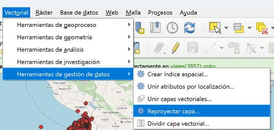

Menú Reproyectar capa.

**9.** Configura:

- **Capa de entrada:** `ECMPO` (zonas costeras de pueblos originarios)
- **SRC objetivo:** `EPSG:3857 - WGS 84 / Pseudo Mercator`

Click en **Aceptar**.

[figure not shown]

Configuración del algoritmo Reproyectar capa para ECMPO.

**10.** Para mantener el orden de tus capas, modifica el nombre de la capa recién proyectada a `ECMPO_reproyectada`. Haz clic derecho sobre la capa y selecciona **Cambiar nombre de la capa**.

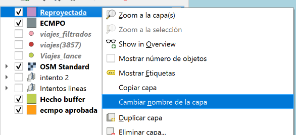

Cambiar nombre de la capa reproyectada.

[figure not shown]

La capa renombrada como ECMPO_reproyectada en el panel de capas.

## Paso 5 | Verificar y limpiar coordenadas con orden de magnitud

**Tip**

**¿Qué estamos haciendo?** Estamos **limpiando los datos** para excluir registros con coordenadas **falsas, nulas o absurdas**. Esto se conoce como aplicar un *“orden de magnitud razonable”* a las coordenadas.

**¿Por qué lo hacemos?** Cuando se trabaja con datos masivos (como lances de pesca industrial), es **común encontrar errores de georreferenciación**: longitudes positivas (como si estuvieran en África), coordenadas 0,0 (en medio del Atlántico), latitudes extremas, etc.

**11.** Haz clic derecho sobre tu capa de lances (`lance(3857)`) → **Abrir tabla de atributos**. Posteriormente, abre la **Calculadora de Campos**.

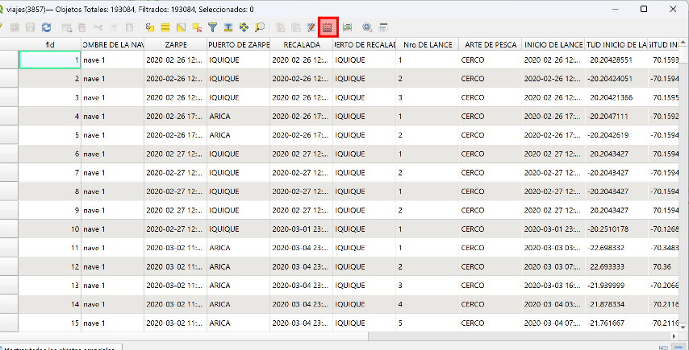

Abrir la Calculadora de Campos desde la tabla de atributos.

**12.** Configura:

- Marca **“Crear un campo nuevo”**
- **Nombre del nuevo campo:** `valido_geo`
- **Tipo del campo de salida:** Entero (32 bit)

Introduce la siguiente expresión:

```
CASE
WHEN
  "LATITUD INICIO DE LANCE"  BETWEEN -60 AND -15 AND
  "LONGITUD INICIO DE LANCE" BETWEEN -80 AND -65 AND
  "LATITUD FIN DE LANCE"     BETWEEN -60 AND -15 AND
  "LONGITUD FIN DE LANCE"    BETWEEN -80 AND -65
THEN 1
ELSE 0
END
```

Haz click en **Aceptar** y cierra la Calculadora de Campos.

[figure not shown]

Calculadora de Campos con la expresión CASE que marca los registros válidos.

**Tip**

## Paso 6 | Seleccionar los lances válidos y exportarlos

**13.** Haz clic en el **ícono de embudo con Epsilon (ε)** → **“Seleccionar por expresión”**.

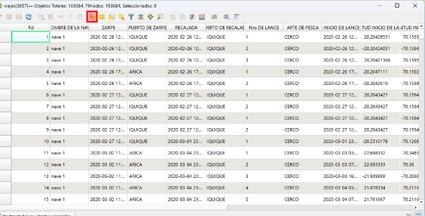

Botón Seleccionar por expresión en la tabla de atributos.

**14.** Escribe: `"valido_geo" = 1`

Haz clic en **Seleccionar → Verás que se seleccionan los lances correctos.**

[figure not shown]

Diálogo de selección por expresión con la condición valido_geo = 1.

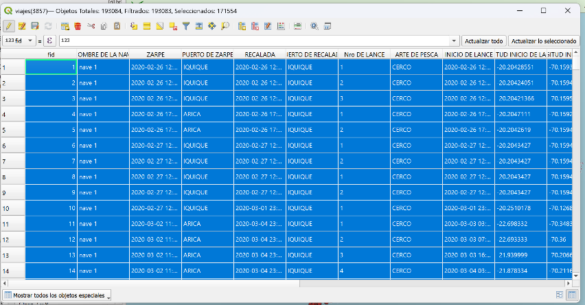

[figure not shown]

Resultado en el mapa: solo los lances con coordenadas válidas quedan seleccionados.

**15.** Exporta como nueva capa. Haz clic derecho sobre la capa de lances → **Exportar → Guardar objetos seleccionados como…**

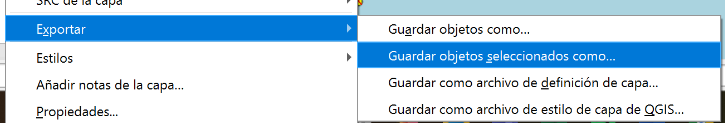

Exportar como nueva capa

**16.** Configura:

- **Formato:** GeoPackage
- **Nombre de archivo:** `lances_filtrados`
- **Nombre de la capa:** `lances_filtrados`
- **SRC:** `EPSG:3857 - WGS 84 / Pseudo Mercator`

Haz clic en **Aceptar**.

[figure not shown]

Guardar los lances filtrados como GeoPackage.

## Paso 7 | Filtrar solo las ECMPO oficialmente decretadas

**Tip**

La capa `ECMPO_reproyectada` contiene tanto **solicitudes** como **ECMPO ya decretadas**. Para nuestro análisis de posibles incumplimiento nos interesan **solo las que ya están oficialmente vigentes**, porque son las que generan la obligación legal.

**17.** Haz clic derecho sobre `ECMPO_reproyectada` → **Abrir tabla de atributos**. Posteriormente, haz click en el **embudo con Epsilon (ε) → “Seleccionar por expresión”**.

**18.** Escribe: `"status" = 'SECTOR DECRETADO'`

[figure not shown]

Selección por expresión: status = ‘SECTOR DECRETADO’.

**19.** Una vez seleccionados los polígonos correspondientes, haz clic derecho sobre la capa → **Exportar → Guardar objetos seleccionados como…**

**20.** Configura:

- **Formato:** GeoPackage
- **Nombre de archivo:** `ecmpo_decretadas`
- **SRC:** `EPSG:3857 - WGS 84 / Pseudo Mercator`

Haz clic en **Aceptar**.

## Paso 8 | Filtrar los lances dentro de la ZEE

**Tip**

**¿Qué es la ZEE?** La **Zona Económica Exclusiva** (ZEE) es la franja de mar jurisdiccional de Chile, que se extiende **370,4 km (200 millas náuticas)** desde la costa. Nos quedamos solo con los lances que ocurrieron **dentro de la ZEE** para asegurarnos de que el análisis se limita a los casos que **sí podrían estar infringiendo la normativa chilena**. Lances en alta mar o en aguas de otros países no se consideran en esta evaluación.

**21.** Seleccionaremos los lances que intersectan la ZEE. Ve a **Seleccionar por localización**.

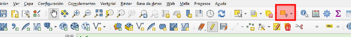

Botón Seleccionar por localización en la barra de herramientas.

**22.** En el panel que se abre:

- **Seleccionar objetos de:** `lances_filtrados`
- **Donde los objetos (predicado geométrico):** `intersecan`
- **Comparando con los objetos de:** `ZEE_Chile`
- **Modificar la selección actual por:** `creando una nueva selección`

Haz clic en **Ejecutar**.

[figure not shown]

Configuración de Seleccionar por localización.

**Nota**

**PAUSA** — debería verse así:

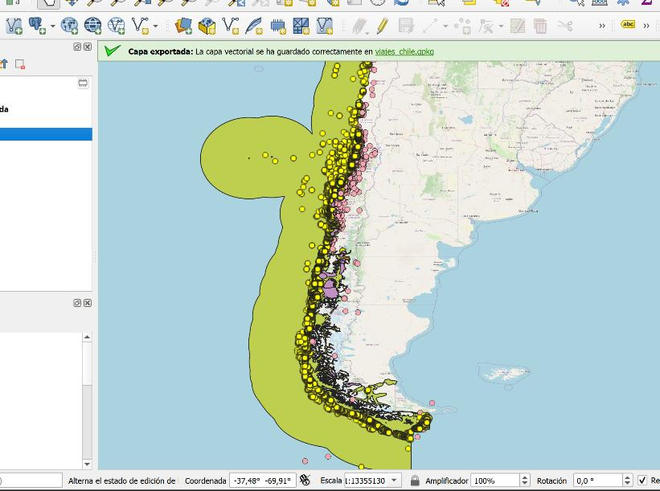

Lances dentro de la ZEE seleccionados; la franja de 200 millas aparece resaltada.

**23.** Exporta como nueva capa. Haz clic derecho sobre la capa de lances → **Exportar → Guardar objetos seleccionados como…**

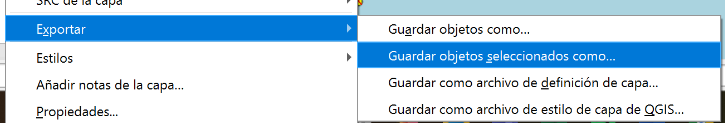

Exportar los lances dentro de la ZEE.

**24.** Configura:

- **Formato:** GeoPackage
- **Nombre de archivo:** `lances_chile_ZEE`
- **Nombre de la capa:** `lances_chile_ZEE`
- **SRC:** `EPSG:3857 - WGS 84 / Pseudo Mercator`

Haz clic en **Aceptar**.

[figure not shown]

Guardar capa lances_chile_ZEE como GeoPackage.

## Paso 9 | Buffer de 5 km alrededor de cada ECMPO decretada

**Nota**

**Zonificación espacial para análisis comparado.** Generaremos un área de **5 km alrededor de cada ECMPO decretada**. Esta es la base para identificar la **presión pesquera en su borde inmediato**.

**25.** Ve al menú **Vectorial → Herramientas de geoproceso → Buffer**.

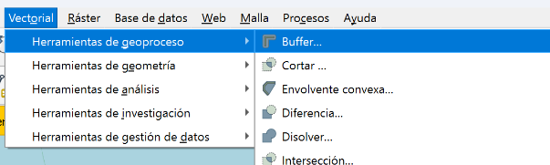

Menú Vectorial > Herramientas de geoproceso > Buffer.

**26.** Configura:

- **Capa de entrada:** `ecmpo_decretadas`
- **Distancia:** `5000` metros
- **No** marcar “Disolver resultado”
- Haz click sobre los puntos suspensivos y posteriormente **Guardar archivo en GeoPackage**

Guarda el archivo Resultado: `buffer_ecmpo_5km`.

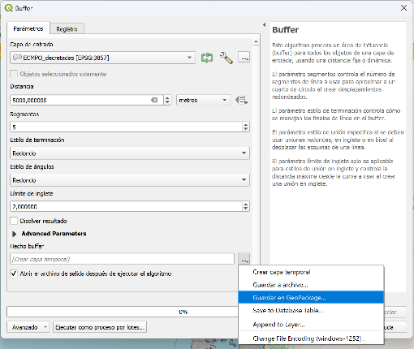

Guardar el buffer como GeoPackage buffer_ecmpo_5km.

**Tip**

Este archivo contiene los buffers **brutos** de 5 km por ECMPO, pero aún podrían solaparse entre sí. Por eso, en el siguiente paso los disolvemos.

## Paso 10 | Disolver los buffers

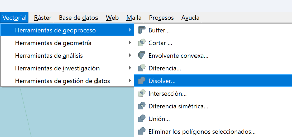

Menú Vectorial > Geoprocesamiento > Disolver.

**28.** Configura:

- **Capa de entrada:** `buffer_ecmpo_5km`
- **Resultado:** `buffer_ecmpo_disueltos`

[figure not shown]

Configuración de Disolver.

**29.** Como se realizó en el paso N°10, para mantener el orden de tus capas, modifica el nombre de la disolución generada a `buffer_ecmpo_disueltos`.

## Paso 11 | Calcular el anillo externo de 5 km

**Tip**

Este paso permite **restar el polígono original de la ECMPO al buffer disuelto**, para así obtener solamente el **anillo externo**, es decir, la zona de borde de 5 km **sin incluir el interior de la ECMPO**. Esto nos permite distinguir los lances que caen *dentro* de la ECMPO vs. los que caen en su *borde inmediato*.

**30.** Ve a **Vectorial → Geoprocesamiento → Diferencia**.

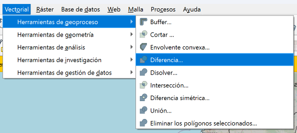

Menú Vectorial > Geoprocesamiento > Diferencia.

**31.** Configura:

[figure not shown]

**32.** Como se realizó en el paso N°29, para mantener el orden de tus capas, modifica el nombre al proceso generado a `anillo_externo_ecmpo`.